# Lab_09T

## Data, Part II

Below we read in a dataset from the UCI Machine Learning Repository. Because it exists elsewhere, I haven’t put it on `GitHub`. If you want to see the raw data and documentation, search for the `HTRU2` dataset.

```r
rm(list=ls())
file.path = "http://www.stat.cmu.edu/~pfreeman/pulsar.Rdata"
load(url(file.path))
rm(file.path)
set.seed(406)
w.0 = which(response$X9==0)
w.1 = which(response$X9==1)
s = sample(length(w.0),length(w.1))
predictors = predictors[c(w.0[s],w.1),]
response = as.character(response$X9)[c(w.0[s],w.1)]
predictors = scale(predictors)
predictors = data.frame(predictors)
cat("Number of predictor variables: ",ncol(predictors),"\n")
```

```
## Number of predictor variables:  8
```

```r
cat("Sample size:                   ",nrow(predictors),"\n")
```

```
## Sample size:                    3278
```

```r
response = factor(response,labels=c("NO","YES"))
response = data.frame(response)
```

Note again that I scaled the predictor data frame!

The eight predictors are summary statistics that describe the distribution of brightness measurements of a pulsar candidate (mean, standard deviation, skewness, kurtosis) as well as the distribution of “dispersion measure” readings (also mean, standard deviation, skewness, kurtosis).

The response is either “NO” (the candidate is *not* a pulsar) or “YES”.

In order to increase computation speed and to make the results “more interesting,” I downsampled the data so as to have 1639 “NO” values and 1639 “YES” values. (There were 1639 “YES” values in the original dataset.)

What’s a pulsar, you ask?

When less massive stars die, they slough off their gaseous outer layers and expose an Earth-sized remnant that is kept from collapsing under gravity by the so-called degeneracy pressure of electrons. Basically, the Pauli Exclusion principle is why these remnants don’t collapse to, e.g., black holes. These are *white dwarfs*.

When stars that are eight times the mass of the Sun or more massive die, they don’t just slowly slough off their gas; they “explode” as supernovae. The remnants left behind are too massive to be held up by electon degeneracy pressure…rather, they collapse to bodies about the size of Pittsburgh that are held up by the degeneracy pressure of neutrons. These are *neutron stars*.

Often times, neutron stars spin. Fast. They also often have really strong magnetic fields that act to “focus” the light they give off into beams. So sometimes, if everything is arranged just so, the neutron star beam of light will hit the Earth, then the star will go dark, then the beam will come around again and hit the Earth. We see pulses of light. Hence…pulsars.

In the end, a pulsar is a Pittsburgh-sized ball of neutrons that whacks us with a radiation beam, perhaps up to tens or hundreds of times per second. You wouldn’t want to live on one, given that the surface gravity is so large you’d be literally instantly crushed into something microscopic. Don’t say you weren’t warned.

## Question 2

You know the drill: split the data, learn a logistic regression model as a baseline, then learn an KNN model and output the test-set MCR values and the confusion matrices for both. (Assume a decision threshold of 0.5. This is not optimal but it is easier to code KNN with this default than otherwise.) Also, like above, use `ggplot()` to display the validation-set MCR versus the number of neighbors. I would have you also create a ROC curve, but the way `FNN` is coded currently makes this relatively difficult to do. Comment on the difference between the MCRs for both models. Also, look at the confusion matrices and comment on where KNN does better than logistic regression. As in Q1, would your conclusion about which model to adopt depend on the needs of the client?

Note that here, instead of using `knn.reg()`, you would use `knn.cv()` to determine the optimum value of $k$, and `knn()` to generate predictions on the test set. Note the `cl` argument for both: this is where `resp.train` goes (since `cl` means “class”). Use the misclassification rate to as your metric for each $k$ value.

Try setting `k.max` to 20.

```r
#split data, logistic regression model learned on split data with test-set assessment

set.seed(100)
fraction=.7
sp = sample(nrow(predictors), round(fraction*nrow(predictors)))
pred.train = predictors[sp ,]
pred.test = predictors[-sp ,]
resp.train = response[sp ,]
resp.test = response[-sp ,]

#logistic regression model using training data
glm.fit = glm(resp.train~.,data=pred.train,family="binomial")
summary(glm.fit)
```

```
##
## Call:
## glm(formula = resp.train ~ ., family = "binomial", data = pred.train)
##
## Deviance Residuals:
##     Min       1Q   Median       3Q      Max
## -4.1309  -0.3041  -0.0341   0.0252   3.0302
##
## Coefficients:
##                Estimate Std. Error z value Pr(>|z|)
## (Intercept)      1.9772     0.6588   3.001 0.002690 **
## profile.mean     0.7523     0.3943   1.908 0.056374 .
## profile.stddev  -0.2551     0.1872  -1.363 0.172957
## profile.skew    12.8567     1.2340  10.419  < 2e-16 ***
## profile.kurt    -7.2510     1.9033  -3.810 0.000139 ***
## dm.mean         -0.9195     0.2444  -3.762 0.000168 ***
## dm.stddev        1.3820     0.3421   4.040 5.35e-05 ***
## dm.skew          0.6165     0.6739   0.915 0.360233
## dm.kurt         -0.6918     0.4525  -1.529 0.126361
## ---
## Signif. codes:  0 '***' 0.001 '**' 0.01 '*' 0.05 '.' 0.1 ' ' 1
##
## (Dispersion parameter for binomial family taken to be 1)
##
##     Null deviance: 3181.39  on 2294  degrees of freedom
## Residual deviance:  768.69  on 2286  degrees of freedom
## AIC: 786.69
##
## Number of Fisher Scoring iterations: 11
```

```r
predicted = predict(glm.fit, pred.test, type="response")

glm.pred=rep("NO", length(response))
glm.pred[predicted >.5]="YES"
tab = table(glm.pred,resp.test)
tab
```

```
##         resp.test
## glm.pred  NO YES
##      NO    1   0
##      YES   7 461
```

```r
(462)/(462+7)
```

```
## [1] 0.9850746
```

```r
#Note that here, instead of using `knn.reg()`, you would use `knn.cv()` to determine the optimum value of $k$, and `knn()` to generate predictions on the test set. Note the `cl` argument for both: this is where `resp.train` goes (since `cl` means "class").

library(FNN)
k.max = 20
mse.k = rep(NA,k.max)
for ( kk in 1:k.max ) {
  knn.out = knn.cv(train=pred.train,cl=resp.train,k=kk,algorithm="brute")
  mse.k[kk] = mean(knn.out != resp.train)
}
k.min = which.min(mse.k)
cat("The optimal number of nearest neighbors is ",k.min,"\n")
```

```
## The optimal number of nearest neighbors is  6
```

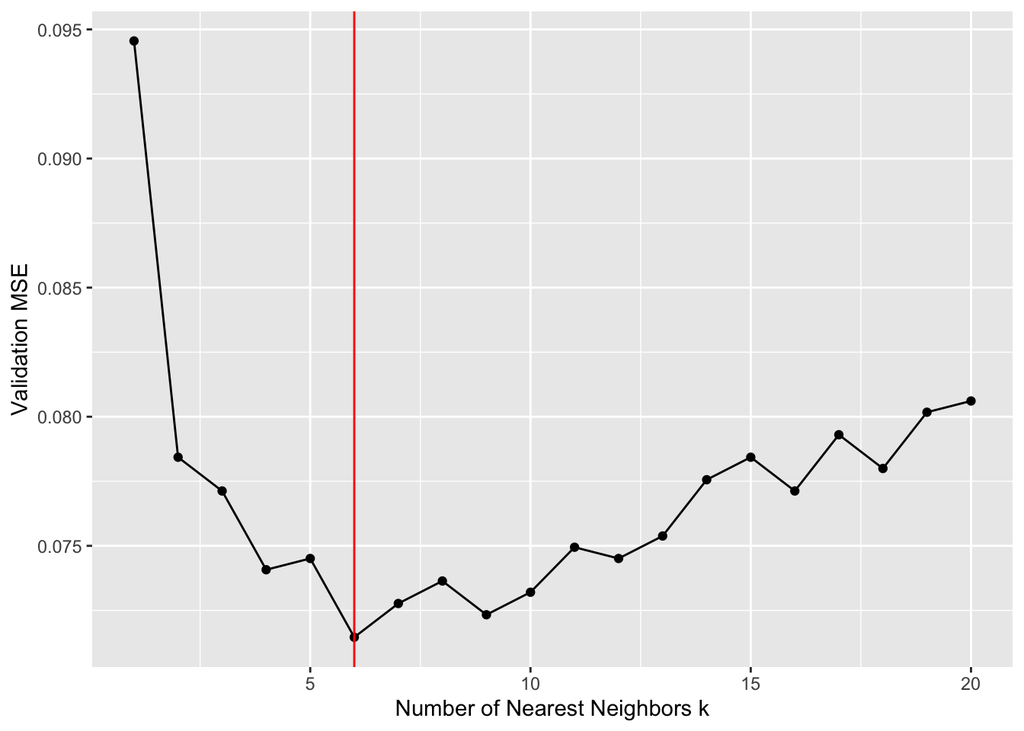

```r
#optimal number of nearest neighbors is 6


#use `ggplot()` to display the validation-set MCR versus the number of neighbors.
suppressMessages(library(tidyverse))
ggplot(data=data.frame("k"=1:k.max,"mse"=mse.k),mapping=aes(x=k,y=mse)) +
  geom_point() + geom_line() +
  xlab("Number of Nearest Neighbors k") + ylab("Validation MSE") +
  geom_vline(xintercept=k.min,color="red")
```

```r
#Call `knn.cv()` again, but this time with both the training and test data, with $k$ set to $k_{\rm opt}$. Use the output to compute the test-set MSE for KNN.

knn.out = knn(train=pred.train,test=pred.test,cl=resp.train,k=k.min,prob=TRUE, algorithm="brute")
(knn.mse = mean(knn.out != resp.test))
```

```
## [1] 0.06103764
```

```r
tab = table(knn.out, resp.test)
tab
```

```
##        resp.test
## knn.out  NO YES
##     NO  473  51
##     YES   9 450
```

```r
(473+450)/(473+450+51+9)
```

```
## [1] 0.9389624
```

```r
1-0.9389624
```

```
## [1] 0.0610376
```

[output not shown]

[output not shown]